# Association and effects

### 1.3.7 Question 7

> Try to write the code needed to reproduce the three charts below. Try to replicate them as closely as possible.

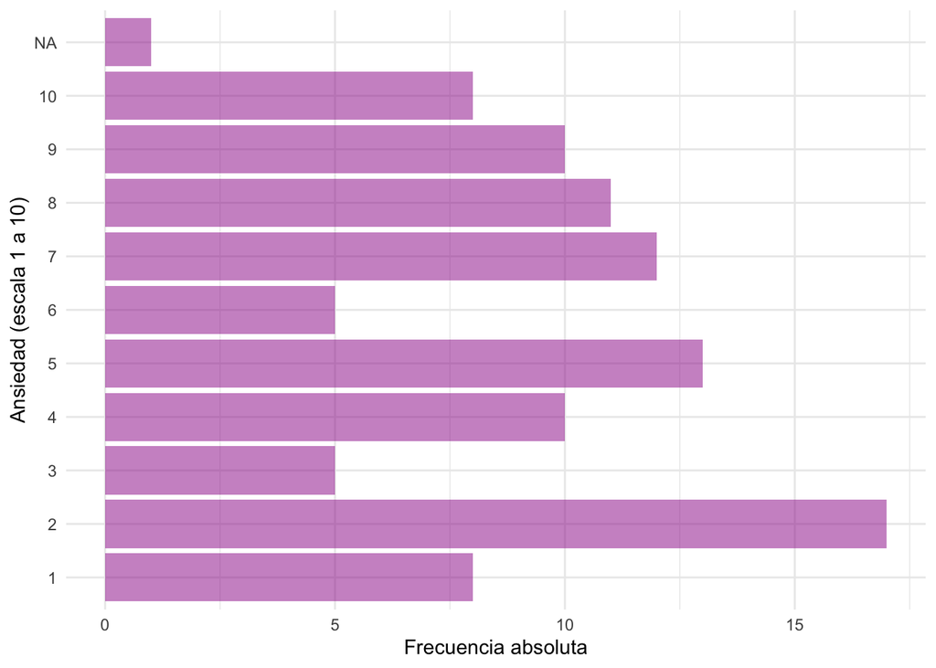

```r
ggplot(datos) +
  geom_bar(aes(y = ansiedad), fill = "#991293", alpha = 0.5) +
  labs(x = "Frecuencia absoluta", y = "Ansiedad (escala 1 a 10)") +
  theme_minimal()
```

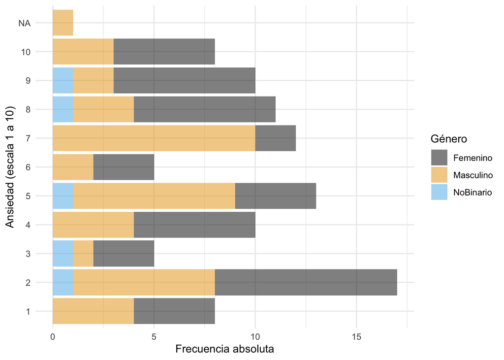

```r
ggplot(datos) +
  geom_bar(aes(y = ansiedad, fill = genero), alpha = 0.5) +
  ggthemes::scale_fill_colorblind() +
  labs(x = "Frecuencia absoluta", y = "Ansiedad (escala 1 a 10)",
       fill = "Género") +
  theme_minimal()
```

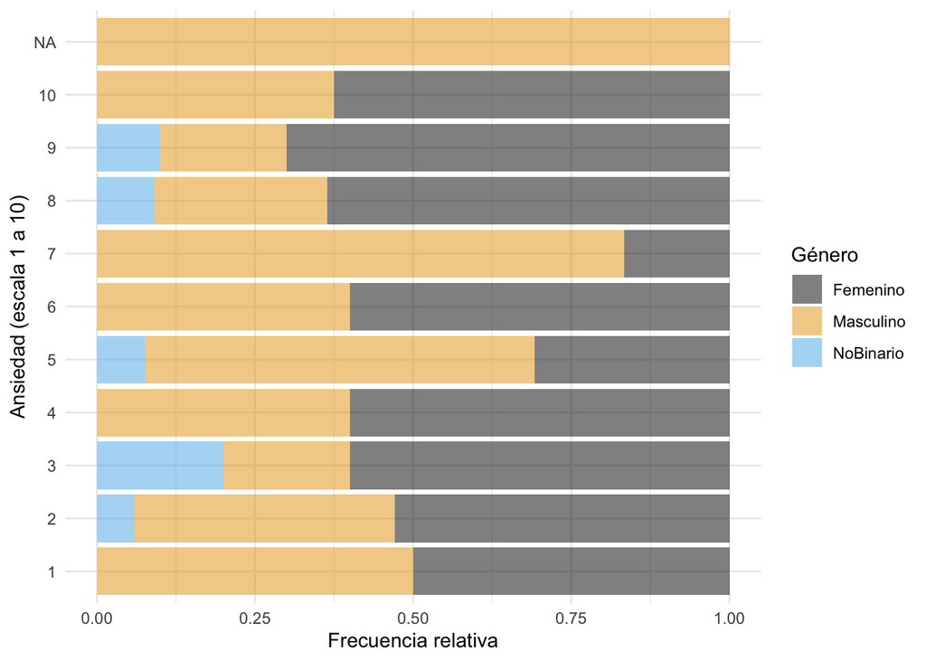

```r
ggplot(datos) +
  geom_bar(aes(y = ansiedad, fill = genero), alpha = 0.5, position = "fill") +
  ggthemes::scale_fill_colorblind() +
  labs(x = "Frecuencia relativa", y = "Ansiedad (escala 1 a 10)",
       fill = "Género") +
  theme_minimal()
```

### 1.3.8 Question 8

> Create an appropriate chart to visualise `depresión` and `ansiedad` at the same time.

```r
# fíjate que aunque sean números, dado que son variables discretas
# de una escala, no permite una correcta visualización un diagrama
# de dispersión ya que hay muchos puntos iguales que se solapan
ggplot(datos) +
  geom_point(aes(x = depresion, y = ansiedad)) +
  theme_minimal()

# una opción: se ve un patrón (tipo "recta ascedente")
ggplot(datos |> count(depresion, ansiedad)) +
  geom_point(aes(x = depresion, y = ansiedad, color = n, size = n)) +
  scale_color_viridis_c() +
  guides(size = "none") +
  theme_minimal()
```

### 1.3.9 Question 9

> Is there an association between gender and drug use? And between depression and anxiety? Quantify your answer as fully as possible and calculate the effect size.

# 2 Cuanti vs cuanti

## 2.1 🐣 Case study I: patient satisfaction survey

We now turn to the relationship between quantitative variables, using the `SatisfaccionPacientes.csv` dataset from Section 1. The main quantitative variables are `edad`, `tiempo_espera`, and `grado_satisfaccion`.

```r
library(readr)
datos <-
  read_csv(file = "./data/SatisfaccionPacientes.csv") |>
  janitor::clean_names() |>
  mutate(estado_civil = factor(estado_civil),
         genero = factor(genero))
```

### 2.1.1 Question 1

> Calculate the covariance matrix and the correlation matrix for the quantitative variables (`edad`, `tiempo_espera`, `grado_satisfaccion`) using `cov()` and `cor()`. What values appear on the diagonal of the covariance matrix? And on the diagonal of the correlation matrix?

```r
datos |>
  select(edad, tiempo_espera, grado_satisfaccion) |>
  cov(use = "complete.obs")

datos |>
  select(edad, tiempo_espera, grado_satisfaccion) |>
  cor(use = "complete.obs")
```

### 2.1.2 Question 2

> Create a scatter plot between `tiempo_espera` (x-axis) and `grado_satisfaccion` (y-axis). Colour the points by `genero` and add a linear trend line with `geom_smooth()`. What pattern do you observe?

```r
ggplot(datos, aes(x = tiempo_espera, y = grado_satisfaccion, color = genero)) +
  geom_point(alpha = 0.6) +
  geom_smooth(method = "lm", se = TRUE) +
  ggthemes::scale_color_colorblind() +
  labs(x = "Waiting time (min)", y = "Satisfaction score",
       color = "Gender") +
  theme_minimal()
```

### 2.1.3 Question 3

> Before choosing a correlation test, check the normality assumption. For both `tiempo_espera` and `grado_satisfaccion`: (a) create a Q-Q plot using `stat_qq()` and `stat_qq_line()`, and (b) run a Shapiro-Wilk test with `shapiro.test()`. Are they normally distributed?

```r
# Q-Q plots
ggplot(datos, aes(sample = tiempo_espera)) +
  stat_qq() + stat_qq_line(color = "red") +
  labs(title = "Q-Q plot: waiting time") +
  theme_minimal()

ggplot(datos, aes(sample = grado_satisfaccion)) +
  stat_qq() + stat_qq_line(color = "red") +
  labs(title = "Q-Q plot: satisfaction score") +
  theme_minimal()

# Shapiro-Wilk normality test
shapiro.test(datos$tiempo_espera)
shapiro.test(datos$grado_satisfaccion)
```

### 2.1.4 Question 4

> Based on the normality results from Question 3, choose and run the appropriate correlation test (`cor.test()`) between `tiempo_espera` and `grado_satisfaccion`. Interpret both the p-value and the effect size. Is the correlation statistically significant? Is it practically relevant?

```r
# if at least one variable is non-normal, use Spearman (non-parametric)
cor.test(datos$tiempo_espera, datos$grado_satisfaccion, method = "spearman")
cor.test(datos$tiempo_espera, datos$grado_satisfaccion, method = "pearson")
```

### 2.1.5 Question 5

> Visualise the full correlation matrix using `{ggcorrplot}`. Which pair of variables shows the strongest linear relationship? Does this match what you computed in Question 1?

```r
library(ggcorrplot)
cor_matrix <-
  datos |>
  select(edad, tiempo_espera, grado_satisfaccion) |>
  cor(use = "complete.obs")

ggcorrplot(cor_matrix, method = "circle", type = "lower",
           lab = TRUE, colors = c("#D85A30", "white", "#1D9E75")) +
  theme_minimal()
```

## 2.2 🐣 Case study II: mental health data

Using the `datos_salud_mental.csv` dataset, we now explore linear relationships between the quantitative variables: `edad`, `sesiones_terapia`, `actividad_fisica`, and `horas_sueno`.

```r
datos <-
  read_csv(file = "./data/datos_salud_mental.csv") |>
  janitor::clean_names() |>
  mutate("id" = as.character(id),
         "genero" = factor(genero), "tipo_drogas" = factor(tipo_drogas),
         "ansiedad" = factor(ansiedad, levels = as.character(1:10), ordered = TRUE),
         "depresion" = factor(depresion, levels = as.character(1:10), ordered = TRUE),
         "uso_drogas_recreativas" = (uso_drogas_recreativas == "Si"))
```

### 2.2.1 Question 1

> Create a scatter plot between `horas_sueno` (x-axis) and `actividad_fisica` (y-axis). Colour the points by `genero` and add a trend line. What pattern do you observe? Does it seem like a strong or weak relationship?

```r
ggplot(datos, aes(x = horas_sueno, y = actividad_fisica, color = genero)) +
  geom_point(alpha = 0.6) +
  geom_smooth(method = "lm", se = TRUE) +
  ggthemes::scale_color_colorblind() +
  labs(x = "Hours of sleep per night", y = "Physical activity (days/week)",
       color = "Gender") +
  theme_minimal()
```

### 2.2.2 Question 2

> Run a Shapiro-Wilk test for each of the four numeric variables (`edad`, `sesiones_terapia`, `actividad_fisica`, `horas_sueno`). Which ones can be assumed to follow a normal distribution? What does this imply for the choice of correlation test?

```r
shapiro.test(datos$edad)
shapiro.test(datos$sesiones_terapia)
shapiro.test(datos$actividad_fisica)
shapiro.test(datos$horas_sueno)
```

### 2.2.3 Question 3

> Based on the normality results, run the appropriate correlation tests between: (a) `sesiones_terapia` and `horas_sueno`, and (b) `edad` and `actividad_fisica`. For each pair, interpret the p-value and the effect size. Is there a statistically significant relationship? Is it practically relevant?

```r
# choose method = "pearson" or "spearman" based on normality results
cor.test(datos$sesiones_terapia, datos$horas_sueno, method = "spearman")
cor.test(datos$edad, datos$actividad_fisica, method = "spearman")
```

### 2.2.4 Question 4

> Compute the Spearman correlation matrix of the four numeric variables and visualise it with `{ggcorrplot}`. Are there any notable associations? Do they make clinical sense?

```r
library(ggcorrplot)
cor_matrix <-
  datos |>
  select(edad, sesiones_terapia, actividad_fisica, horas_sueno) |>
  cor(use = "complete.obs", method = "spearman")

ggcorrplot(cor_matrix, method = "circle", type = "lower",
           lab = TRUE, colors = c("#D85A30", "white", "#1D9E75")) +
  labs(title = "Spearman correlation matrix: mental health dataset") +
  theme_minimal()
```

### 2.2.5 Question 5

> Save both correlation matrices (satisfaction survey and mental health) as a single `.csv` file using `write_csv()`. Hint: use `as.data.frame()` to convert each matrix first, add a column identifying the dataset, then combine with `bind_rows()`.

```r
cor_satisfaccion <-
  read_csv(file = "./data/SatisfaccionPacientes.csv") |>
  janitor::clean_names() |>
  select(edad, tiempo_espera, grado_satisfaccion) |>
  cor(use = "complete.obs") |>
  as_tibble() |>
  mutate(dataset = "satisfaction", variable = rownames(cor_matrix))

cor_salud <-
  cor_matrix |>
  as_tibble() |>
  mutate(dataset = "mental_health", variable = rownames(cor_matrix))

bind_rows(cor_satisfaccion, cor_salud) |>
  write_csv(file = "./data/correlation_matrices.csv")
```

# 3 infer package

## 3.1 🐣 Case study I: mammals sleep

We wil work on an updated and expanded version of the mammals sleep dataset. Updated sleep times and weights were taken from V. M. Savage and G. B. West. A quantitative, theoretical framework for understanding mammalian sleep. Proceedings of the National Academy of Sciences, 104 (3):1051-1056, 2007.

```r
library(tidyverse)
msleep
```

```
# A tibble: 83 × 11
   name   genus vore  order conservation sleep_total sleep_rem sleep_cycle awake
   <chr>  <chr> <chr> <chr> <chr>              <dbl>     <dbl>       <dbl> <dbl>
 1 Cheet… Acin… carni Carn… lc                  12.1      NA        NA      11.9
 2 Owl m… Aotus omni  Prim… <NA>                17         1.8      NA       7
 3 Mount… Aplo… herbi Rode… nt                  14.4       2.4      NA       9.6
 4 Great… Blar… omni  Sori… lc                  14.9       2.3       0.133   9.1
 5 Cow    Bos   herbi Arti… domesticated         4         0.7       0.667  20
 6 Three… Brad… herbi Pilo… <NA>                14.4       2.2       0.767   9.6
 7 North… Call… carni Carn… vu                   8.7       1.4       0.383  15.3
 8 Vespe… Calo… <NA>  Rode… <NA>                 7        NA        NA      17
 9 Dog    Canis carni Carn… domesticated        10.1       2.9       0.333  13.9
10 Roe d… Capr… herbi Arti… lc                   3        NA        NA      21
# ℹ 73 more rows
# ℹ 2 more variables: brainwt <dbl>, bodywt <dbl>
```

### 3.1.1 Question 1

> Variable `conservation` contains the conservation status of the animal, bein `ex`, `ew`, `cr`, `en` and `vu` categories for extinct and/or high risk of extinction animals. Create a new variable `threatened` that contains 1 if conservation is one of the previous status, and 0 otherwise

```r
msleep <-
  msleep |>
  mutate("threatened" =
           conservation %in% c("ex", "ew", "cr", "en", "vu"))
```

### 3.1.2 Question 2

> The goal will be to answer the question: is there an association between diet (carnivore, omnivore, insectivore, or herbivore) and conservation status (threatened or not)? To begin, build the appropriate frequency table to answer:
1. What % of carnivores are threatened?
2. What % of non-threatened animals are herbivores?
3. Out of the total data, what % are threatened insectivores?

```r
prop.table(table(msleep$vore, msleep$threatened), margin = 1) # 26.32%
prop.table(table(msleep$vore, msleep$threatened), margin = 2) # 41.54%
prop.table(table(msleep$vore, msleep$threatened)) # 1.32%
```

### 3.1.3 Question 3

> Create the plot you consider most appropriate to visually assess whether an association exists or not

```r
msleep |>
  drop_na(threatened, vore) |>
  ggplot() +
  geom_bar(aes(x = vore, fill = threatened),
           position = "fill", alpha = 0.7) +
  scale_y_continuous(labels = scales::label_percent()) +
  ggthemes::scale_fill_colorblind() +
  theme_minimal() +
  labs(x = "Dieta", y = "Frecuencia relativa",
       fill = "¿Amenazado?")

msleep |>
  drop_na(threatened, vore) |>
  ggplot() +
  geom_bar(aes(x = threatened, fill = vore),
           position = "fill", alpha = 0.7) +
  scale_y_continuous(labels = scales::label_percent()) +
  ggthemes::scale_fill_colorblind() +
  theme_minimal() +
  labs(x = "¿Amenazado?", y = "Frecuencia relativa",
       fill = "Dieta")
```

### 3.1.4 Question 4

> We are going to answer the question of whether there is an effect or not, for which we need a p-value. Review the slides and answer: are the assumptions for running a chisq.test() met? If not, carry out the test using a permutation test, obtaining a p-value and a confidence interval. Reflect on the results

```r
# 1. Comprobamos hipótesis (necesitamos n >= 5 en cada uno)
table(msleep$threatened, msleep$vore)
# No se cumple --> haremos permutaciones

library(infer)

# Generamos permutaciones BAJO LA NULA
null_dist <-
  msleep |> drop_na(threatened, vore) |>
  specify(threatened ~ vore, success = "TRUE") |>
  hypothesize(null = "independence") |>
  generate(reps = 5000, type = "permute") |>
  # para cada permutación calculamos estadístic chisq
  calculate(stat = "Chisq")

# Calculamos estadístico observado
obs_stat <-
  msleep |> drop_na(threatened, vore) |>
  specify(threatened ~ vore, success = "TRUE") |>
  calculate(stat = "Chisq")

# Cuantíficamos p-valor empírico
# p-value = proporción de Chisq simulados > obs_stat
null_dist |>
  # chi-cuadrado es >=
  get_p_value(obs_stat, direction = "greater")
# p-value = 0.125

# Cuantíficamos incertidumbre: CI
ci <-
  msleep |> drop_na(threatened, vore) |>
  specify(threatened ~ vore, success = "TRUE") |>
  generate(reps = 5000, type = "bootstrap") |>
  calculate(stat = "Chisq") |>
  get_confidence_interval(level = 0.95, type = "percentile")
# [3.14, 18.9] del estadístico

# Visualizamos
null_dist |>
  visualize() +
  shade_p_value(obs_stat, direction = "greater")

# Conclusión
# No podemos rechazar la hipótesis nula =>
# No hay evidencias suficientes para decir que
# hay un efecto de la dieta en la supervivencia
# Aunque
```

### 3.1.5 Question 5

> Run the code you consider appropriate to answer the following question: is the average brain weight 0.3 kg? Provide a p-value and a confidence interval. If the null hypothesis is rejected: is the difference with respect to 0.3 considerable?

```r
# 1. Establecer hipótesis
# H0: \mu = 0.3

# 2. Visualizar datos + hipótesis
msleep |>
  ggplot() +
  geom_density(aes(x = brainwt), fill = "gold", alpha = 0.5) +
  geom_vline(xintercept = 0.3, linetype = "dashed", color = "darkred") +
  geom_vline(aes(xintercept = mean(brainwt)), linetype = "dashed", color = "steelblue") +
  theme_minimal()
# Claramente no es normal (ni simétrica!)

# 3. Comprobar normalidad
# en este caso es bastante obvio pero bueno
shapiro.test(msleep$brainwt)
ggplot(msleep, aes(sample = brainwt)) + geom_qq() + geom_qq_line()

# NO podemos hacer un contraste paramétrico
# Opción 1: wilcoxon --> no deberíamos ya que no es simétrica
wilcox.test(x = msleep$brainwt, mu = 0.3)
# de hecho sale que rechazaríamos

# Opción 2 (la que deberiamos hacerr): p-value simulado
null_dist <-
  msleep |>
  specify(response = brainwt) |>
  hypothesize(null = "point", mu = 0.3) |>
  generate(reps = 5000, type = "bootstrap") |>
  calculate(stat = "mean")
obs_stat <-
  msleep |>
  specify(response = brainwt) |>
  calculate(stat = "mean")
# otra forma
obs_stat <-
  msleep |>
  observe(response = brainwt, stat = "mean")
null_dist |>
  get_p_value(obs_stat, direction = "two-sided")
# p-value = 0.251
null_dist |>
  visualize() +
  shade_p_value(obs_stat, direction = "two-sided")

# CI
ci <-
  msleep |>
  specify(response = brainwt) |>
  generate(reps = 5000, type = "bootstrap") |>
  calculate(stat = "mean") |>
  get_confidence_interval(level = 0.95, type = "percentile")
# 95% CI = [0.0746, 0.566]
# No podemos rechazar la hipótesis nula
# No hay evidencias suficientes para decir que es distinto de 0.3
```

### 3.1.6 Question 6

> Crea una nueva variable que represente el % del peso total del animal que representa su cerebro (peso relativo del cerebro). Tras ello crea otra variable que agrupe a los animales en dos grupos: herbívoros y no herbívoros (incluyendo en este último grupo a los NA).

```r
msleep <-
  msleep |>
  mutate("relative_brainwt" = 100*brainwt/bodywt,
         "herbi" = case_when(is.na(vore) ~ "no herbi",
                             vore == "herbi" ~ "herbi",
                             TRUE ~ "no herbi"))
```

### 3.1.7 Question 7

```r
# H_0: mu_{herbi} = mu_{no herbi}
# ==> H_0: mu_{herbi} - mu_{no herbi} = 0
# ==> H_0: relative brain wt vs herbi are independent

msleep  <-
  msleep |>
  mutate("relative_brainwt" = 100*brainwt/bodywt)

# 1. Visualizamos datos
msleep |>
  ggplot(aes(x = herbi, y = relative_brainwt,
             fill = herbi, color = herbi)) +
  geom_boxplot(alpha = 0.4) +
  stat_summary(fun = "mean", geom = "point", shape = 18, size = 5) +
  MetBrewer::scale_fill_met_d(palette_name = "Renoir") +
  MetBrewer::scale_color_met_d(palette_name = "Renoir") +
  theme_minimal()

msleep |>
  ggplot(aes(x = herbi, y = relative_brainwt, color = herbi)) +
  geom_jitter(alpha = 0.5) +
  stat_summary(fun = "mean", geom = "point", shape = 18, size = 5) +
  MetBrewer::scale_fill_met_d(palette_name = "Renoir") +
  MetBrewer::scale_color_met_d(palette_name = "Renoir") +
  theme_minimal()
# parece que hay bastante distancia a favor de los no herbi

# 2. ¿Cumple hipótesis para paramétrico?
msleep |>
  summarise("p_val" = shapiro.test(relative_brainwt)$p.value, .by = herbi)
ggplot(msleep, aes(sample = relative_brainwt)) +
  geom_qq() +
  geom_qq_line() +
  facet_wrap(~herbi) +
  theme_minimal()
# los no herbi no parecen seguir una normal

# varianzas iguales
library(car)
leveneTest(relative_brainwt ~ herbi, data = msleep)
# si parece cumplirse


# opciones: mann-whitney o permutaciones
# chequeamos hipótesis mann-whitney
# 1. misma forma
msleep |>
  ggplot(aes(x = relative_brainwt, fill = herbi)) +
  geom_density(alpha = 0.5) +
  MetBrewer::scale_fill_met_d(palette_name = "Renoir")
  theme_minimal()
# no parecen tener la misma forma
ks.test(x = msleep$relative_brainwt[msleep$herbi == "herbi"],
        y = msleep$relative_brainwt[msleep$herbi == "no herbi"])
# ks.test testea si las dos distribuciones son la misma

# usando plot + ks.test --> no son iguales/misma forma
# --> usamos permutaciones
set.seed(1234)
null_dist <-
  msleep |>
  drop_na(relative_brainwt, herbi) |>
  specify(relative_brainwt ~ herbi) |>
  hypothesize(null = "independence") |>
  generate(reps = 1000, type = "permute") |>
  calculate(stat = "diff in means", order = c("herbi", "no herbi"))

obs_stat <-
  msleep |>
  drop_na(relative_brainwt, herbi) |>
  observe(relative_brainwt ~ herbi, stat = "diff in means",
          order = c("herbi", "no herbi"))

null_dist |>
  get_p_value(obs_stat, direction = "two-sided")
# p-value = 0.05

set.seed(1234)
ci <-
  msleep |>
  drop_na(relative_brainwt, herbi) |>
  specify(relative_brainwt ~ herbi) |>
  generate(reps = 1000, type = "bootstrap") |>
  calculate(stat = "diff in means", order = c("herbi", "no herbi")) |>
  get_confidence_interval(level = 0.95, type = "percentile")
# CI = [-0.956, 0.0524] (para la diferencia de medias)
# La conclusión honesta no es "hay efecto" ni "no hay efecto"
# es "los datos están en el límite y el resultado es sensible al método.

# de hecho el effect size
cohens_d(data = msleep, relative_brainwt ~ herbi)
# devuelve -0.55 con un IC de [-1.10, 0.01]
# puede no tener efecto, puede ser negativo, o puede ser hasta positivo

# nada concluyente (la vida a veces es dura, honestidad >> forzar resultados)
```

### 3.1.8 Question 8

> Which plot would you use to visualize the potential relationship between sleep hours (sleep_total) and relative brain weight (relative_brainwt)?

```r
msleep |>
  ggplot(aes(x = sleep_total, y = relative_brainwt)) +
  geom_point(aes(color = vore), size = 2.5) +
  geom_smooth(method = "lm", se = FALSE) +
  theme_minimal()
# a priori parece que existe una relación
# no sabemos todavía si suficiente
# y no sebemos todavía si lineal
```

### 3.1.9 Question 9

> Is there a relationship between both variables (sleep_total vs relative_brainwt)? Run the code you consider appropriate to answer the question

```r
# 1. comprobamos normalidad de ambas
shapiro.test(msleep$sleep_total)
shapiro.test(msleep$relative_brainwt)
ggplot(msleep, aes(sample = sleep_total)) + geom_qq() + geom_qq_line()
ggplot(msleep, aes(sample = relative_brainwt)) + geom_qq() + geom_qq_line()
# una de ellas no es --> calculamos spearman

# coefficient = 0.370 (relación positiva, más % cerebro, más duermen)
# p-value = 0.00506 --> existe una relación monótona entre entre ambas
msleep |>
  drop_na(relative_brainwt, sleep_total) |>
  summarise("cor_coeff" =
              cor(relative_brainwt, sleep_total, method = "spearman"),
            "cor_pvalue" =
              cor.test(relative_brainwt, sleep_total, method = "spearman")$p.value)

# esto es equivalente a Pearson aplicado a rangos
msleep |>
  drop_na(relative_brainwt, sleep_total) |>
  mutate(across(c(relative_brainwt, sleep_total), rank)) |>
  summarise("cor_coeff" = cor(relative_brainwt, sleep_total),
            "cor_pvalue" =
              cor.test(relative_brainwt, sleep_total)$p.value)

# equivalente (¡pero no lo necesitamos aquí!)
null_dist <-
  msleep |>
  drop_na(relative_brainwt, sleep_total) |>
  mutate(across(c(relative_brainwt, sleep_total), rank)) |>
  specify(relative_brainwt ~ sleep_total) |>
  hypothesize(null = "independence") |>
  # podemos ya que bajo independencia, los valores de (x, y) tendrían
  # que poder ser intercambiales (ya que no hay relación entre ellas)
  generate(reps = 5000, type = "permute") |>
  calculate(stat = "correlation")

obs_stat <-
  msleep |>
  drop_na(relative_brainwt, sleep_total) |>
  mutate(across(c(relative_brainwt, sleep_total), rank)) |>
  observe(relative_brainwt ~ sleep_total, stat = "correlation")
null_dist |>
  get_p_value(obs_stat, direction = "two-sided")
```

# 4 Cuanti vs cuali (2 groups)

## 4.1 🐣 Case study II: turnout vs candidates

The blackturnout.csv file contains voter turnout data from U.S. congressional elections in 2006, 2008, and 2010, for each state. The variables are:

- `turnout`: voter turnout rate among the Black population in the most recent in-person elections (as a proportion of the Black voting-age population)
- `cvap`: proportion of Black residents in the district (as a proportion of the total voting-age population)
- `candidate`: 1 if the candidate belongs to the Black population; 0 otherwise.

```r
datos <-
  read_csv(file = "./data/blackturnout.csv") |>
  janitor::clean_names()
```

```
──────────────────────────────────────────────────────── Delimiter: "," chr
(1): state dbl (6): ...1, year, district, turnout, CVAP, candidate
```

```r
datos
```

```
# A tibble: 1,237 × 7
      x1  year state district turnout   cvap candidate
   <dbl> <dbl> <chr>    <dbl>   <dbl>  <dbl>     <dbl>
 1     1  2008 AK           0   0.710 0.0350         0
 2     2  2010 AK           0   0.448 0.0323         0
 3     3  2010 AK           1   0.448 0.0323         0
 4     4  2008 AK           1   0.710 0.0350         0
 5     5  2006 AK           1   0.439 0.0318         0
 6     6  2010 AL           0   0.397 0.256          0
 7     7  2008 AL           0   0.626 0.253          1
 8     8  2010 AL           1   0.374 0.261          0
 9     9  2006 AL           1   0.266 0.261          0
10    10  2008 AL           1   0.620 0.261          0
# ℹ 1,227 more rows
```

### 4.1.1 Question 1

> How many states had a Black candidate in each election? How many Black candidates were there in each state for each election?

```r
datos |>
  summarise("black_candidate" = sum(candidate), .by = c(year))

datos |>
  summarise("black_candidate" = sum(candidate), .by = c(year, state))
```

### 4.1.2 Question 2

> Which plot would you use to visualize a potential relationship between turnout (voter participation) and cvap (proportion of Black population in the district)? Do it in a way that distinguishes the year in the plot

```r
# todo junto separado por colores
datos |>
  ggplot(aes(x = turnout, y = cvap, color = factor(year))) +
  geom_point(alpha = 0.5, size = 3) +
  geom_smooth(method = "lm", se = FALSE) +
  ggthemes::scale_color_colorblind() +
  theme_minimal()

# facetado y separado por colores
datos |>
  ggplot(aes(x = turnout, y = cvap, color = factor(year))) +
  geom_point(alpha = 0.5, size = 3) +
  geom_smooth(method = "lm", se = FALSE) +
  ggthemes::scale_color_colorblind() +
  facet_wrap(~factor(year)) +
  theme_minimal()
```

### 4.1.3 Question 3

> Is there an association between turnout (voter participation) and cvap (proportion of Black population in the district)? If so, what is the size and direction of the effect?

```r
# ¿son normales?
shapiro.test(datos$turnout)
shapiro.test(datos$cvap)
# turnout podría serlo
ggplot(datos, aes(sample = turnout)) + geom_qq() + geom_qq_line()

# cvap imposible
ggplot(datos, aes(sample = cvap)) + geom_qq() + geom_qq_line()

# coefficient = 0.204 (relación positiva, más proporción engra, más % de participación) ==> ¿más comunidad, más red sociales y políticas que incentiva el voto?
# p-value = 4.18e-13 --> existe una relación monótona entre entre ambas
datos |>
  drop_na(turnout, cvap) |>
  summarise("cor_coeff" =
              cor(turnout, cvap, method = "spearman"),
            "cor_pvalue" =
              cor.test(turnout, cvap, method = "spearman")$p.value)

# intenta replicar lo de antes con infer pero nos va a salir lo mismo
# saca los CI si quieres

# el efecto es de 0.204 y positivo: una crece, la otra también
```

### 4.1.4 Question 4

> Does the presence of a Black candidate in the district influence Black voter turnout? Is there an effect of such a candidate? If so, how large is this effect? Quantify and conclude using all available tools, detailing each of the conclusions obtained (with reasoning).

```r
# cuanti vs cuali: a

# 1. Visualizamos cuanti frente a cuali
# boxplot
ggplot(datos,
       aes(x = factor(candidate), y = turnout,
           color = factor(candidate), fill = factor(candidate))) +
  geom_boxplot(alpha = 0.5) +
  stat_summary(fun = "mean", geom = "point", shape = 18, size = 4) +
  MetBrewer::scale_fill_met_d(palette_name = "Renoir") +
  MetBrewer::scale_color_met_d(palette_name = "Renoir") +
  guides(color = "none") +
  labs(x = "Candidato negro", y = "Participación (negra)",
       fill = "¿Candidato negro?") +
  theme_minimal()

# violin
ggplot(datos,
       aes(x = factor(candidate), y = turnout,
           color = factor(candidate), fill = factor(candidate))) +
  geom_violin(alpha = 0.5) +
  stat_summary(fun = "mean", geom = "point", shape = 18, size = 4) +
  MetBrewer::scale_fill_met_d(palette_name = "Renoir") +
  MetBrewer::scale_color_met_d(palette_name = "Renoir") +
  guides(color = "none") +
  labs(x = "Candidato negro", y = "Participación (negra)",
       fill = "¿Candidato negro?") +
  theme_minimal()

# jitter
ggplot(datos,
       aes(x = factor(candidate), y = turnout,
           color = factor(candidate))) +
  geom_jitter(alpha = 0.1) +
  stat_summary(fun = "mean", geom = "point", shape = 18, size = 4) +
  MetBrewer::scale_color_met_d(palette_name = "Renoir") +
  labs(x = "Candidato negro", y = "Participación (negra)",
       color = "¿Candidato negro?") +
  theme_minimal()
# en promedio (mediana y media) hay más participación negra
# cuando hay candidatos negros

# 2. ¿Ese efecto es significativo?
# t-test 2 sample
# H0: particip_{candidato negro} = particip_{sin candidato negro}
# H0: particip_{candidato negro} - particip{sin candidato negro} = 0
# H0: Participacion vs Candidato son independientes

# descriptivamente
datos |>
  summarise("mean_turnout" = mean(turnout),
            "median_turnout" = median(turnout), .by = candidate)
# ¿suficiente grande la diferencia para considerarlas suficiente?

# chequeamos condiciones
shapiro.test(datos$turnout[datos$candidate == 1])
shapiro.test(datos$turnout[datos$candidate == 0])
datos |>
  ggplot(aes(sample = turnout)) + geom_qq() + geom_qq_line() +
  facet_wrap(~candidate) +
  theme_minimal()
# no parecen

# ¿podemos aplicar mann-whitney?
datos |>
  ggplot(aes(x = turnout, fill = factor(candidate))) +
  geom_density(alpha = 0.4) +
  theme_minimal()
# parecen tener exactamente la misma forma pero desplazada
# podemos aplicar mann-whitney (0 - 1)
wilcox.test(turnout ~ candidate, alternative = "two.sided",
            conf.int = TRUE, conf.level = 0.95, data = datos)
# p-value < 0.00001
# rechazamos hipótesis nula ==> P(X > Y) no es 0.5 ==>
# hay algún grupo con una tendencia/gap mayorq ue la otra
# por el gráfico, la tabla resumen y los signos del IC vemos además que es
# participación_{candidato negro} > participación_{no candidato negro}

# calculamos tamaño del efecto
rank_biserial(turnout ~ candidate, data = datos)
# rank-biserial correlation r_rb = -0.23 cuyo CI es [-0.32, -0.13]
# r_rb =2*P−1 donde P = P(grupo 1> grupo 0) ==>
# P = (r_rb + 1) / 2
# Es decir, si coges al azar un distrito sin candidato negro y otro candidato negro,
# la probabilidad de que el grupo 1 tenga mayor turnout es (1+0.23)/2=0.615
# el 61.5% de las veces, habrá más particiapción negra en distritos con
# candidato negro que sin él => hay un efecto moderado (el azar sería 50%)
# fuerte sería aprox 0.5 (75% de las veces)

# con lo anterior sabemos que existe efecto pero la respuesta
# no tiene nada que ver con las medias
# si queremos responder exactamente a la pregunta de las medias --> permute
null_dist <-
  datos |>
  mutate("candidate" = factor(candidate)) |>
  specify(turnout ~ candidate) |>
  hypothesize(null = "independence") |>
  generate(reps = 10000, type = "permute") |>
  calculate(stat = "diff in means", order = c("1", "0"))

obs_stat <-
  datos |>
  mutate("candidate" = factor(candidate)) |>
  specify(turnout ~ candidate) |>
  calculate(stat = "diff in means", order = c("1", "0"))

null_dist |>
  get_p_value(obs_stat, direction = "two-sided")
null_dist |>
  visualize() +
  shade_p_value(obs_stat, direction = "two-sided")
# p-value = 0 ==> rechazamos (dentro de la precisión que tenemos)
# la diferencia de medias obtenida es más alta que
# todas las 10000 simulaciones ejecutadas bajo la igualddad de medias

ci <-
  datos |>
  mutate("candidate" = factor(candidate)) |>
  specify(turnout ~ candidate) |>
  generate(reps = 10000, type = "bootstrap") |>
  calculate(stat = "diff in means", order = c("1", "0")) |>
  get_confidence_interval(level = 0.95, type = "percentile")
# 95% CI para la diferencia de medias = [0.0336, 0.0912]

cohens_d(turnout ~ candidate,
        data = datos |>
          mutate("candidate" = factor(candidate, levels = c(1, 0))))
# Tamaño del efecto: 0.36 ([0.19, 0.53])
# la diferencia de medias es 0.36 veces la sd de los datos

# IMPORTANTE
# La respuesta a "¿hay efecto?" es la misma ==> sí
# pero el cómo justificarlo es distinta ya que las preguntas
# de la H0 son diferentes
# Mann-Whitney: ¿P(X > Y) = 0.5?
# permutacones: la pregunta original mu_X = mu_Y
# depende de que necesites reportar puedes hacer uno u otro
# o ambos (siempre que se cumplan condiciones)
```

## 4.2 🐣 Case study III: Bechdel test

The bechdel dataset from the `{fivethirtyeight}` R package contains information on 1,794 films released between 1970 and 2013, originally compiled for a FiveThirtyEight article on gender representation in Hollywood. Each row is a movie, and the key variables include whether the film passes the Bechdel test — a minimal bar for female representation requiring (1) at least two named women, (2) who talk to each other, (3) about something other than a man — along with financial data such as budget, domestic and international gross revenue, and return on investment (ROI), all adjusted for inflation.

```r
library(fivethirtyeight)
bechdel
```

```
# A tibble: 1,794 × 15
    year imdb      title  test  clean_test binary budget domgross intgross code
   <int> <chr>     <chr>  <chr> <ord>      <chr>   <int>    <dbl>    <dbl> <chr>
 1  2013 tt1711425 21 & … nota… notalk     FAIL   1.3 e7 25682380   4.22e7 2013…
 2  2012 tt1343727 Dredd… ok-d… ok         PASS   4.50e7 13414714   4.09e7 2012…
 3  2013 tt2024544 12 Ye… nota… notalk     FAIL   2   e7 53107035   1.59e8 2013…
 4  2013 tt1272878 2 Guns nota… notalk     FAIL   6.1 e7 75612460   1.32e8 2013…
 5  2013 tt0453562 42     men   men        FAIL   4   e7 95020213   9.50e7 2013…
 6  2013 tt1335975 47 Ro… men   men        FAIL   2.25e8 38362475   1.46e8 2013…
 7  2013 tt1606378 A Goo… nota… notalk     FAIL   9.2 e7 67349198   3.04e8 2013…
 8  2013 tt2194499 About… ok-d… ok         PASS   1.20e7 15323921   8.73e7 2013…
 9  2013 tt1814621 Admis… ok    ok         PASS   1.3 e7 18007317   1.80e7 2013…
10  2013 tt1815862 After… nota… notalk     FAIL   1.3 e8 60522097   2.44e8 2013…
# ℹ 1,784 more rows
# ℹ 5 more variables: budget_2013 <int>, domgross_2013 <dbl>,
#   intgross_2013 <dbl>, period_code <int>, decade_code <int>
```

### 4.2.1 Question 1

> Do movies that pass the Bechdel test (`binary` variable) have a lower budget than those that don’t?

```r
# 1. visualizar
# boxplot
ggplot(bechdel,
       aes(x = binary, y = budget, color = binary, fill = binary)) +
  geom_boxplot(alpha = 0.5) +
  stat_summary(fun = "mean", geom = "point", shape = 18, size = 4) +
  MetBrewer::scale_fill_met_d(palette_name = "Renoir") +
  MetBrewer::scale_color_met_d(palette_name = "Renoir") +
  guides(color = "none") +
  labs(x = "Bechdel test", y = "Budget",
       fill = "Bechdel test") +
  theme_minimal()

# violin
ggplot(bechdel,
       aes(x = binary, y = budget, color = binary, fill = binary)) +
  geom_violin(alpha = 0.5) +
  stat_summary(fun = "mean", geom = "point", shape = 18, size = 4) +
  MetBrewer::scale_fill_met_d(palette_name = "Renoir") +
  MetBrewer::scale_color_met_d(palette_name = "Renoir") +
  guides(color = "none") +
  labs(x = "Bechdel test", y = "Budget",
       fill = "Bechdel test") +
  theme_minimal()

# jitter
ggplot(bechdel, aes(x = binary, y = budget, color = binary)) +
  geom_jitter(alpha = 0.1) +
  stat_summary(fun = "mean", geom = "point", shape = 18, size = 4) +
  MetBrewer::scale_color_met_d(palette_name = "Renoir") +
  labs(x = "Bechdel test", y = "Budget", color = "Bechdel test") +
  theme_minimal()
# en promedio (mediana y media) tienen más presupuesto
# las películas con menos protagonismo de mujeres

# 2. ¿Ese efecto es significativo?
# t-test 2 sample
# H0: budget_{fail} - budget_{pass} = 0
# H0: budget vs fail/pass test

# descriptivamente
bechdel |>
  summarise("mean_budget" = mean(budget),
            "median_budget" = median(budget), .by = binary)
# ¿suficiente grande la diferencia para considerarlas suficiente?

# chequeamos condiciones
shapiro.test(bechdel$budget[bechdel$binary == "PASS"])
shapiro.test(bechdel$budget[bechdel$binary == "FAIL"])
bechdel |>
  ggplot(aes(sample = budget)) + geom_qq() + geom_qq_line() +
  facet_wrap(~binary) +
  theme_minimal()
# no parecen

# ¿podemos aplicar mann-whitney?
bechdel |>
  ggplot(aes(x = budget, fill = binary)) +
  geom_density(alpha = 0.4) +
  theme_minimal()
# parecen tener formas parecidas
wilcox.test(budget ~ binary, alternative = "two.sided",
            conf.int = TRUE, conf.level = 0.95, data = bechdel)
# p-value < 0.00001
# rechazamos hipótesis nula ==> P(X > Y) no es 0.5 ==>
# fail > pass (tendencia/gap mayor que la otra)

# calculamos tamaño del efecto
rank_biserial(budget ~ binary, data = bechdel)
# rank-biserial correlation r_rb = 0.15 ([0.1, 0.2])
# r_rb =2*P−1 => P = (r_rb + 1) / 2 = 0.575
# Si coges al azar una película que pase el test y otra que no
# ña que no pasa el test tenga más presupuesto
# sucede el 57.5% de las veces => hay un efecto leve

# con lo anterior sabemos que existe efecto pero la respuesta
# no tiene nada que ver con las medias
# si queremos responder exactamente a la pregunta de las medias --> permute
null_dist <-
  bechdel |>
  specify(budget ~ binary) |>
  hypothesize(null = "independence") |>
  generate(reps = 10000, type = "permute") |>
  calculate(stat = "diff in means", order = c("FAIL", "PASS"))

obs_stat <-
  bechdel |>
  specify(budget ~ binary) |>
  calculate(stat = "diff in means", order = c("FAIL", "PASS"))

null_dist |>
  get_p_value(obs_stat, direction = "two-sided")
null_dist |>
  visualize() +
  shade_p_value(obs_stat, direction = "two-sided")
# p-value = 0 ==> rechazamos (dentro de la precisión que tenemos)
# la diferencia de medias obtenida es más alta que
# todas las 10000 simulaciones ejecutadas bajo la igualdad de medias

ci <-
  bechdel |>
  specify(budget ~ binary) |>
  generate(reps = 10000, type = "bootstrap") |>
  calculate(stat = "diff in means", order = c("FAIL", "PASS")) |>
  get_confidence_interval(level = 0.95, type = "percentile")
# 95% CI para la diferencia de medias = [8 137 269$, 16 800 209$]
# puede haber hasta 16 millones de diferencia de presupuesto

cohens_d(budget ~ binary, data = bechdel)
# Tamaño del efecto: 0.26 ([0.17, 0.35])
# la diferencia de medias es 0.26 veces la sd de los datos
```

### 4.2.2 Question 2

> Has the proportion of movies passing the Bechdel test changed across decades?

```r
bechdel <-
  bechdel |>
  mutate("decade" = round(year, -1))
```

```r
# 1. Visualizar
# proporción de PASS por década
bechdel |>
  count(decade, binary) |>
  ggplot(aes(x = decade, y = n)) +
  geom_col(aes(fill = binary), position = "fill", alpha = 0.7) +
  geom_hline(yintercept = 0.5, linetype = "dashed", color = "red") +
  scale_y_continuous(labels = scales::label_percent()) +
  ggthemes::scale_fill_colorblind() +
  labs(x = "década", y = "% PASS", fill = "Bechdel test") +
  theme_minimal()

# ¿Verifica condiciones chi-sq?
table(bechdel$decade, bechdel$binary)

# Sí: test chi-cuadrado -> ¿hay asociación entre década y PASS/FAIL?
chisq.test(bechdel$decade, bechdel$binary)
# p-value < 0.00001
# si hay relación entre década y pass/fail
# según el gráfico además parece aumentar hasta 2000

# Tamaño del efecto
bechdel |>
  select(decade, binary) |>
  table() |>
  cramers_v()
# effect size = 0.12 ([0.07, 1.00])
# Aunque la proporción de películas que pasan el test ha variado
# entre décadas, esa variación es modesta (efecto pequeño)
```

### 4.2.3 Question 3

> Do more than 50% of movies pass the Bechdel test?

```r
# Proporción observada
bechdel |>
  count(binary) |>
  mutate(prop = n / sum(n))

bechdel |>
  ggplot() +
  geom_bar(aes(x = binary, fill = binary), alpha = 0.7) +
  ggthemes::scale_fill_colorblind() +
  labs(x = "% PASS", y = "n", fill = "Bechdel test") +
  theme_minimal()

# Contraste de proporciones
# H0: p = 0.5 (bilateral)
# H1: p ≠ 0.5
# donde p = número de películas PASS / total de películas
null_dist <-
  bechdel |>
  specify(response = binary, success = "PASS") |>
  hypothesize(null = "point", p = 0.5) |>
  # cuando tenemos una proporción el tipo es draw
  # simula tirar una moneda con la probabilidad p de arriba
  generate(reps = 5000, type = "draw") |>
  calculate(stat = "prop")

obs_stat <-
  bechdel |>
  specify(response = binary, success = "PASS") |>
  calculate(stat = "prop")
# 0.448

# p-valor bilateral
null_dist |>
  get_p_value(obs_stat, direction = "two-sided")
# p-valor unilateral (¿más del 50%?)
null_dist |>
  get_p_value(obs_stat, direction = "greater")
# no rechaza la nula H0: p < 0.5
# recuerda que la pregunta (p >= 0.5) siempre va en la H1

# Visualización
null_dist |>
  visualize() +
  shade_p_value(obs_stat, direction = "greater")

# CI boostrap
bechdel |>
  specify(response = binary, success = "PASS") |>
  generate(reps = 5000, type = "bootstrap") |>
  calculate(stat = "prop") |>
  get_confidence_interval(level = 0.95, type = "percentile")
```

# 5 Cuanti vs cuali (> 2 groups)

## 5.1 🐣 Case study I: age problem

```r
library(fivethirtyeight)
congress_age
```

```
# A tibble: 18,635 × 13
   congress chamber bioguide firstname middlename lastname  suffix birthday
      <int> <chr>   <chr>    <chr>     <chr>      <chr>     <chr>  <date>
 1       80 house   M000112  Joseph    Jefferson  Mansfield <NA>   1861-02-09
 2       80 house   D000448  Robert    Lee        Doughton  <NA>   1863-11-07
 3       80 house   S000001  Adolph    Joachim    Sabath    <NA>   1866-04-04
 4       80 house   E000023  Charles   Aubrey     Eaton     <NA>   1868-03-29
 5       80 house   L000296  William   <NA>       Lewis     <NA>   1868-09-22
 6       80 house   G000017  James     A.         Gallagher <NA>   1869-01-16
 7       80 house   W000265  Richard   Joseph     Welch     <NA>   1869-02-13
 8       80 house   B000565  Sol       <NA>       Bloom     <NA>   1870-03-09
 9       80 house   H000943  Merlin    <NA>       Hull      <NA>   1870-12-18
10       80 house   G000169  Charles   Laceille   Gifford   <NA>   1871-03-15
# ℹ 18,625 more rows
# ℹ 5 more variables: state <chr>, party <chr>, incumbent <lgl>,
#   termstart <date>, age <dbl>
```

## 5.2 🐣 Case study II: attractiveness vs alcohol

## 5.3 🐣 Case study III: idealista

## 5.4 🐣 Case study IV: spotify_songs

## 5.5 🐣 Case study V: us_avg_tuition